# hPHH_DRW

Sem

2025-05-10

## Libraries

```r
library(ggplot2)
library(data.table)
library(dplyr)
library(tibble)
library(purrr)
library(progressr)
library(WGCNA)
library(tidyr)
```

## PHH Data

```r
data_dir <- "C:/Users/semde/Documents/BOO_Scripts/Data/PHH_TXG-MAPr"
expression_long   <- readRDS(file.path(data_dir, "expression_long.rds"))
module_definition        <- readRDS(file.path(data_dir, "module_definition.rds"))
module_annotation <- readRDS(file.path(data_dir, "module_annotation.rds"))
GRR_vs_eg_score          <- readRDS(file.path(data_dir, "GRR_vs_eg_score_PHH.rds"))
```

```r
adj_matrix <- fread(file.path(data_dir, "adj_PHH.txt")) %>%
  as.data.frame() %>%
  column_to_rownames(var = names(.)[1]) %>%
  as.matrix()
```

```
## Warning in fread(file.path(data_dir, "adj_PHH.txt")): Detected 10275 column
## names but the data has 10276 columns (i.e. invalid file). Added an extra
## default column name for the first column which is guessed to be row names or an
## index. Use setnames() afterwards if this guess is not correct, or fix the file
## write command that created the file to create a valid file.
```

The adj matrix reading gives a warning but reading in went well, so warning is ignored.

# Introduction

In this Rmd file, the Weighted Directed Random Walk will be performed on the PHH dataset.This involves performing a random walk over the network, where nodes present genes and edges present the directions of the network. The procedures described by (Hui et al, 2024) and (Liu et al, 2013) are followed as much as possible. However, they used predefined pathways and this project used co-expressed modules. So, some things will differ and it will be mentioned where it differs.

First, the directions of the network will be constructed based on the median(TOM) values of genes in a module, if media(TOM(gene A)) > median(TOM(gene B)) than A has an edge to B: A->B (represented as 1). This direction will be weighted by the Topological Overlap Matrix (TOM). *The original article uses predefined pathways for this.* Then, the directions will be reversed, because “a web page is important if other pages point to it” and therefore also genes (Liu et al, 2013). Also,an artificial ground node will be used, which is bidirectionally connected to every gene that has no connections to other genes and one directionally connected to every other gene. This is done to make sure that every node is connected and there are no 0-out of degree connections (Liu et al, 2013), making sure that the progation goes well and the walker converges. This results in the Weighted Graph $G$.

After that, the random walker will be performed:

$$W_{t+1} = (1 - r) A_{M_j} \cdot W_t + r W_0$$
Here, the $r$ represents the restart probability, set at 0.7 (Hui et al). This represents the chance to return to the initial weight vector ($W_0$), which represents the initial differential signal for each gene, based on biological and statistical significance: -log10(padj) * abs(Log2FC). *The original article used t-values, but the degrees of freedom are not known. So this score is proposed.*

$$W_0(g_i) = -\log_{10} \left( p_{\mathrm{adj}}(g_i) \right) \cdot \left|
\log_2 \mathrm{FC}(g_i) \right|$$

The $A_{Mj}$ represents the row normalized adjacency matrix of the Graph $G$. The $W_t$ vector represents the weight of the nodes (genes) at time $t$ and the $W_{t+1}$ vector represents the weight of the nodes (genes) at time $t+1$.

The recursive walker will be performed until the L1-norm ,the difference (delta), between $W_t$ and $W_{t+1}$ converges to $10^{–10}$ and this limit, the $W_{∞}$, will be obtained for each gene. The $W_{∞}$ of the ground node will be evenly distributed over the other genes in the module.

Afterwards, the module activty for module $M_j$ will be calculated using the following formula, only using genes that have a padj < 0.05 and an absolute log2fc greater than 1.0:

## Inspecting the adjacency matrix

First, the adj matrix will be inspected

```r
dim(adj_matrix)
```

```
## [1] 10275 10275
```

```r
head(adj_matrix[, 1:5])
```

```
##               51514_at     9518_at     2669_at     29760_at     26959_at
## 51514_at  1.0000000000 0.057220455 0.007769394 0.0005873794 0.0866797151
## 9518_at   0.0572204547 1.000000000 0.080204939 0.0096070438 0.1685868984
## 2669_at   0.0077693938 0.080204939 1.000000000 0.0008329760 0.0492083413
## 29760_at  0.0005873794 0.009607044 0.000832976 1.0000000000 0.0009031884
## 26959_at  0.0866797151 0.168586898 0.049208341 0.0009031884 1.0000000000
## 153222_at 0.0878481259 0.155628774 0.068101526 0.0018787177 0.5024712486
```

```r
min(adj_matrix)
```

```
## [1] 2.521592e-42
```

```r
max(adj_matrix)
```

```
## [1] 1
```

```r
sum(adj_matrix[1, ])
```

```
## [1] 124.2146
```

```r
sum(adj_matrix[2, ])
```

```
## [1] 29.4248
```

adj matrix goes from ~0 to 1. and the x features have the same length as the y features, as expected due to it being an adjacency matrix. But rows are not normalized yet, this will have to be done for every module in the walker formula.

## Calculating the Topological Overlap Matrix (TOM)

The TOM will be calculated to weight the directions of the graphs.

```r
#TOM <- TOMsimilarity(adj_matrix)
```

```r
#dimnames(TOM) <- dimnames(adj_matrix)
```

```r
TOM   <- readRDS(file.path(data_dir, "TOM_PHH.rds"))
```

```r
head(TOM[, 1:5])
```

```
##              id_51514    id_9518    id_2669    id_29760    id_26959
## id_51514  1.000000000 0.06804939 0.03450293 0.008083006 0.065665945
## id_9518   0.068049390 1.00000000 0.02293214 0.006390410 0.052047455
## id_2669   0.034502931 0.02293214 1.00000000 0.002630120 0.042334232
## id_29760  0.008083006 0.00639041 0.00263012 1.000000000 0.005361233
## id_26959  0.065665945 0.05204745 0.04233423 0.005361233 1.000000000
## id_153222 0.063341415 0.06591273 0.05612424 0.008132504 0.076470658
```

As shown above, the TOM matrix calculation worked and the genes now have different values. Potentially, more topologically correct. This TOM will be used to weight the directions of the graph.

But the TOM had different names. It has genenumber_at instead of id_genenumber. So this will be corrected:

```r
# Columns
#colnames(TOM) <- paste0("id_", gsub("_at$", "", colnames(TOM))) # remove _at at the end and add id_ at the front

# Rows
#rownames(TOM) <- paste0("id_", gsub("_at$", "", rownames(TOM))) # remove _at at the end and add id_ at the front
```

ensure that the TOM is a matrix

```r
is.matrix(TOM)
```

```
## [1] TRUE
```

```r
dim(TOM)
```

```
## [1] 10275 10275
```

```r
head(TOM[, 1:5])
```

```
##              id_51514    id_9518    id_2669    id_29760    id_26959
## id_51514  1.000000000 0.06804939 0.03450293 0.008083006 0.065665945
## id_9518   0.068049390 1.00000000 0.02293214 0.006390410 0.052047455
## id_2669   0.034502931 0.02293214 1.00000000 0.002630120 0.042334232
## id_29760  0.008083006 0.00639041 0.00263012 1.000000000 0.005361233
## id_26959  0.065665945 0.05204745 0.04233423 0.005361233 1.000000000
## id_153222 0.063341415 0.06591273 0.05612424 0.008132504 0.076470658
```

The TOM now have correct row and column names.

```r
#saveRDS(TOM, file = "TOM_PHH.rds")
```

# NA values

Checking for NA values

```r
sum(is.na(expression_long$padj)) # Na values in padj
```

```
## [1] 0
```

```r
sum(is.na(expression_long$padj) & is.na(expression_long$log2fc))
```

```
## [1] 0
```

No NA values

# Calculating W0 for the Directed Random Walker

The walker requires t-scores (Hui et al, 2024) for constructing the initial weight (W0), however the degrees of freedom are not known. So therefore, a different score will be used. For this the “walker score” will be used, which is proposed as the abs(Log2FC) * -log10(padj). To account for statistical significance and biological significance.

```r
expression_long$walker_score <- abs(expression_long$log2fc) *
                                         (-log10(expression_long$padj))
```

```r
sum(is.na(expression_long$walker_score))
```

```
## [1] 0
```

No NA values

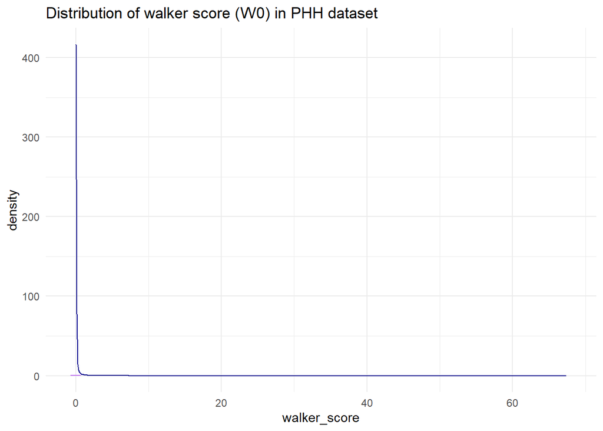

```r
ggplot(expression_long, aes(x = walker_score)) +
  geom_histogram(aes(y = ..density..), bins = 50, fill = "purple", alpha = 0.6) +
  geom_density(color = "darkblue") +
  theme_minimal() + labs(title = "Distribution of walker score (W0) in PHH dataset")
```

heavily skewed, but will be normalized in the activity calculation.

# Join the module_definition with the expression_long_filtered df

The module definition will be joined with the gene expression data to assign every gene to the corresponding module for later use in the random walk.

```r
expression_joined <- expression_long %>%
  left_join(module_definition %>% select(entrez_id, module_number), by = "entrez_id")
```

# Constructing the Directed Graph

To construct the Directed Graph for use in the Directed Random Walk. The Median(TOM) scores will be used for genes in the same module. If median(TOM(gene A)) > median(TOM(gene B)) than A has an edge to B: A->B. Then the directions will be reversed: a webpage is important if other webpages point to it (Hui et al, 2024). This directed Graph will then be weighted by the TOM values. Resulting in a weighted Directed Graph.

## Correlation EGs

The correlation EG, calculated by LACDR, will be joined with the expression_joined df. **The cor_egs are not used anymore, but are still included here.**

```r
expression_cor_eg <- expression_joined %>%
  # Remove module 0
  filter(module_number != 0) %>%

  # Join gene-level correlation scores from module_definition
  left_join(
    module_definition %>% select(entrez_id, module_number, cor_eg = corr_egs),
    by = c("entrez_id", "module_number")
  )
```

```r
sum(is.na(expression_cor_eg$cor_eg))
```

```
## [1] 0
```

## Calculating the Directed Graph

The directed graph will be calculated in the walker loop.

# Perform the walker on one module to learn how it works

Before performing the walker on the whole PHH dataset, it will be tested on one module to assess how it works exactly. Module 295 was selected with condition “TG_HPHH_SINGLE_ACETAMINOPHEN_T3_C3”.

## Defining the module and condition for the testing

```r
module_nr = 295
condition_id = "TG_HPHH_SINGLE_ACETAMINOPHEN_T3_C3"
```

## Preparing the data for the condition and module

```r
# Subset the module

expr_sub <- expression_cor_eg %>%
  filter(module_number == module_nr, sample_id == condition_id)

genes_in_module <- expr_sub$entrez_id
cor_vec <- expr_sub$cor_eg
names(cor_vec) <- expr_sub$entrez_id
```

```r
genes_in_TOM <- intersect(genes_in_module, rownames(TOM))
cor_vec <- cor_vec[genes_in_TOM]
TOM_sub <- TOM[genes_in_TOM, genes_in_TOM]
```

## Defining the Directed Graph

Again, if median(TOM(A)) > median(TOM(B)) then edge: A -> B. However, these edges will be reverted: a gene is important if other genes point to it (Liu et al, 2013)

```r
TOM_medians <- apply(TOM_sub, 1, median, na.rm = TRUE)
```

```r
print(TOM_medians)
```

```
##   id_23657   id_26504    id_6541    id_8140   id_81631   id_83667
## 0.03379483 0.03414400 0.03764860 0.03839390 0.04584154 0.03728079
```

```r
# Directional Graph based on TOM median
D <- outer(TOM_medians, TOM_medians, FUN = function(x, y) as.numeric(x < y))
rownames(D) <- colnames(D) <- names(TOM_medians)

W_directed <- D * TOM_sub # Weight the directions with the TOM
```

## Adding a ground node

A ground node will be added to ensure that the walker does not get stuck on a gene without outgoing edges. (Liu et al, 2013)

```r
genes <- rownames(W_directed)
ground_node <- "GROUND"
n <- length(genes)

# Maak empty matrix
W_plus <- matrix(0, nrow = n + 1, ncol = n + 1)
rownames(W_plus) <- colnames(W_plus) <- c(genes, ground_node)

# Add original matrix
W_plus[genes, genes] <- W_directed

# Add ground node to genes without outgoing edges
zero_rows <- which(rowSums(W_directed) == 0)
if (length(zero_rows) > 0) {
  W_plus[genes[zero_rows], ground_node] <- 1e-4  # This will be normalized to "1" later

  # Ground node has equal weight to every other gene in the module
  W_plus[ground_node, genes] <- 1
}

# Normalization of the matrix
diag(W_plus) <- 0
row_sums <- rowSums(W_plus)
  row_sums[row_sums == 0] <- 1e-10  # prevent division by zero (not possible if all goes well)
  A <- W_plus / row_sums
```

```r
sum(A[1, ])
```

```
## [1] 1
```

```r
sum(A[2, ])
```

```
## [1] 1
```

```r
print(A)
```

```
##           id_23657  id_26504   id_6541   id_8140  id_81631  id_83667 GROUND
## id_23657 0.0000000 0.1917351 0.1515172 0.1998820 0.2746362 0.1822296      0
## id_26504 0.0000000 0.0000000 0.2034297 0.1917132 0.3370059 0.2678512      0
## id_6541  0.0000000 0.0000000 0.0000000 0.5384062 0.4615938 0.0000000      0
## id_8140  0.0000000 0.0000000 0.0000000 0.0000000 1.0000000 0.0000000      0
## id_81631 0.0000000 0.0000000 0.0000000 0.0000000 0.0000000 0.0000000      1
## id_83667 0.0000000 0.0000000 0.2751897 0.3150809 0.4097295 0.0000000      0
## GROUND   0.1666667 0.1666667 0.1666667 0.1666667 0.1666667 0.1666667      0
```

```r
print(expr_sub)
```

```
## # A tibble: 6 × 9
##   entrez_id gene_symbol log2fc      pvalue      padj sample_id      walker_score
##   <chr>     <chr>        <dbl>       <dbl>     <dbl> <chr>                 <dbl>
## 1 id_23657  id_SLC7A11   1.60  0.000000248 0.0000224 TG_HPHH_SINGL…        7.43
## 2 id_26504  id_CNNM4     1.27  0.00000161  0.0000633 TG_HPHH_SINGL…        5.32
## 3 id_6541   id_SLC7A1   -0.288 0.00474     0.0162    TG_HPHH_SINGL…        0.515
## 4 id_8140   id_SLC7A5   -0.421 0.00152     0.00659   TG_HPHH_SINGL…        0.919
## 5 id_81631  id_MAP1LC3B  0.957 0.0000120   0.000211  TG_HPHH_SINGL…        3.52
## 6 id_83667  id_SESN2     0.467 0.000227    0.00157   TG_HPHH_SINGL…        1.31
## # ℹ 2 more variables: module_number <dbl>, cor_eg <dbl>
```

## Defining the initial probability, based on the ‘walker score’

The initial probability will be assigned on the earlier calculated walker score.

```r
# Prepare the initial walker probability (W0) based on the proposed walker score.
  # Initialize W0 with all genes 0
  W0 <- rep(0, length(rownames(A)))
  names(W0) <- rownames(A)

  # Select only the walker score for significant genes
  W0_sig <- expr_sub %>%
    filter(entrez_id %in% rownames(A)) %>% # , padj < 0.05 was left out to reduce over estimation
    select(entrez_id, walker_score) %>%
    tibble::deframe()

  # Fill W0 only for significant genes
  W0[names(W0_sig)] <- abs(W0_sig)

  # Normalization
  W0 <- W0 / sum(W0)

  # Security: make sure the genes match
  stopifnot(all(names(W0) == rownames(A)))
```

```r
print(W0)
```

```
##   id_23657   id_26504    id_6541    id_8140   id_81631   id_83667     GROUND
## 0.39093304 0.27972448 0.02712133 0.04834706 0.18502477 0.06884932 0.00000000
```

```r
print(expr_sub$walker_score)
```

```
## [1] 7.4304710 5.3167280 0.5154957 0.9189334 3.5167690 1.3086202
```

a higher walker score recieves a higher W0 as intended.

## Running the walker

```r
# Run random walk with restart

r <- 0.7
W_prev <- W0
convergence <- data.frame(iteration = 0, delta = NA)
W_all <- list(W_prev)

for (i in 1:1000) {
  W_new <- (1 - r) * A %*% W_prev + r * W0
  delta <- sum(abs(W_new - W_prev))
  convergence <- rbind(convergence, data.frame(iteration = i, delta = delta))
  W_all[[i + 1]] <- W_new
  if (delta < 1e-10) break
  W_prev <- W_new
}

W_inf <- as.numeric(W_new)
names(W_inf) <- rownames(A)
```

```r
print(summary(W_inf))
```

```
##    Min. 1st Qu.  Median    Mean 3rd Qu.    Max.
## 0.04406 0.06390 0.07721 0.13217 0.18335 0.30944
```

```r
print(W_inf)
```

```
##   id_23657   id_26504    id_6541    id_8140   id_81631   id_83667     GROUND
## 0.30943831 0.22397169 0.05113335 0.07666331 0.14273457 0.07720725 0.04405742
```

```r
print(expr_sub$padj)
```

```
## [1] 2.235799e-05 6.326264e-05 1.617531e-02 6.587185e-03 2.108446e-04
## [6] 1.568835e-03
```

### Distributing the final weight of the ground node

The final weight of the ground node will be evenly distributed across all other nodes.

```r
if ("GROUND" %in% names(W_inf)) {
  ground_mass <- W_inf["GROUND"]
  W_inf <- W_inf[names(W_inf) != "GROUND"]
  W_inf <- W_inf + ground_mass / length(W_inf)
}
```

```r
print(W_inf)
```

```
##   id_23657   id_26504    id_6541    id_8140   id_81631   id_83667
## 0.31678121 0.23131460 0.05847626 0.08400622 0.15007747 0.08455015
```

No ground node left and evenly distributed over the other genes in the module.

## Visualizations

The walker output will be visualized to understand it better

### Visualization of the convergence

First the L1-norm, the difference between $W_t$ and $W_{t+1}$, will be visualized to assess how the walker converges.

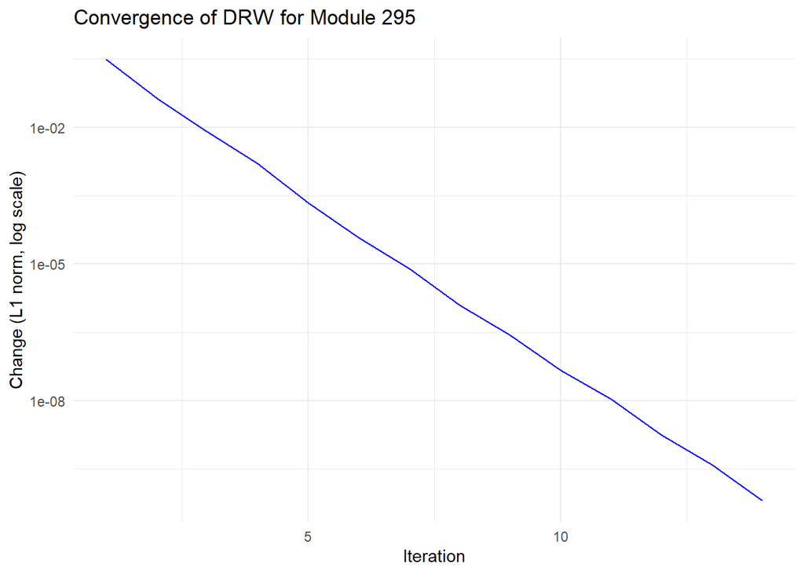

```r
# Visualize convergence

ggplot(convergence[-1, ], aes(x = iteration, y = delta)) +
  geom_line(color = "blue") +
  scale_y_log10() +
  labs(title = paste("Convergence of DRW for Module", module_nr),
       x = "Iteration", y = "Change (L1 norm, log scale)") +
  theme_minimal()
```

As shown above, the L1-norm decreases after iterations, making the walker converge.

### Visualizations of the weight vectors

Here the meanof the $W_0$ and $W_t$ vectors will be visualized.

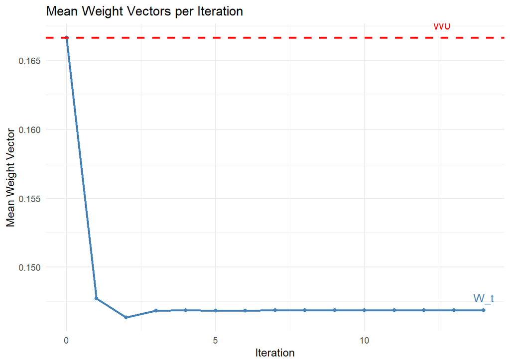

```r
# Preprocessing for visualization
walker_matrix <- do.call(cbind, W_all)
colnames(walker_matrix) <- paste0("iter_", seq_along(W_all) - 1)

# Remove ground node
walker_matrix <- walker_matrix[rownames(walker_matrix) != "GROUND", , drop = FALSE]

# Calculate mean scores of the W_t vector
mean_scores <- colMeans(walker_matrix, na.rm = TRUE)

# Mean of W0
mean_w0 <- mean_w0 <- mean(W0[names(W0) != "GROUND"])

# Create dataframe for visualization
mean_df <- tibble(
  iteration = seq_along(mean_scores) - 1,
  mean_score = mean_scores
)

last_iter <- max(mean_df$iteration)
last_score <- mean_df$mean_score[mean_df$iteration == last_iter]

ggplot(mean_df, aes(x = iteration, y = mean_score)) +
  geom_line(color = "steelblue", linewidth = 1) +
  geom_point(size = 1.5, color = "steelblue") +
  geom_hline(yintercept = mean_w0, color = "red", linetype = "dashed", linewidth = 1) +
  annotate("text", x = last_iter, y = last_score, label = "W_t", color = "steelblue", vjust = -1) +
  annotate("text", x = max(mean_df$iteration) * 0.9, y = mean_w0, label = "W0", color = "red", vjust = -1) +
  labs(title = "Mean Weight Vectors per Iteration",
       x = "Iteration", y = "Mean Weight Vector") +
  theme_minimal()
```

Above could be seen how the weight vectors change. It is shown that the W_t vector converges to a stable value, which is below the W0 vector in this module.

## Inferring pathway activity

Calculate the activity of the module with the output $W_{∞}$ for the genes. Only genes with an adjusted p-value < 0.05 and log2fc > 1.0 will be used in the calculation.

```r
activity_df <- expression_joined %>%
  filter(sample_id == condition_id,
         entrez_id %in% names(W_inf),
         padj < 0.05, abs(log2fc) > 1.0) %>%
  select(entrez_id, log2fc) %>%
  mutate(W_inf = W_inf[entrez_id],
         term = W_inf * log2fc)

numerator <- sum(activity_df$term, na.rm = TRUE)
denominator <- sqrt(sum(activity_df$W_inf^2, na.rm = TRUE))
pathway_activity_score <- numerator / denominator
```

```r
# Output
cat("DRW pathway activity score for module", module_nr, "in condition", condition_id, ":\n")
```

```
## DRW pathway activity score for module 295 in condition TG_HPHH_SINGLE_ACETAMINOPHEN_T3_C3 :
```

```r
print(pathway_activity_score)
```

```
## [1] 2.037083
```

```r
connectivity <- rowSums(TOM_sub)

print(
  activity_df %>%
    left_join(
      expression_joined %>%
        filter(sample_id == condition_id) %>%
        select(entrez_id, padj),
      by = "entrez_id"
    ) %>%
    mutate(connectivity = connectivity[entrez_id])
)
```

```
## # A tibble: 2 × 6
##   entrez_id log2fc W_inf  term      padj connectivity
##   <chr>      <dbl> <dbl> <dbl>     <dbl>        <dbl>
## 1 id_23657    1.60 0.317 0.506 0.0000224         1.17
## 2 id_26504    1.27 0.231 0.293 0.0000633         1.16
```

Above shows the genes that were used in the activity calculation. The connectivity column is the sum of the TOM rows.